# Class 03 ToothGrowth Example

- Show All Code
- Hide All Code
- View Source

Author

Thomas E. Love, Ph.D.

Published

2026-08-28

## R Setup

```r
knitr::opts_chunk$set(comment = NA)

source("data/Love-431.R")

library(janitor)
library(knitr)
library(patchwork)
library(rstanarm)
library(easystats)
library(tidyverse)

theme_set(theme_bw())
```

# 1 The ToothGrowth data

## 1.1 Show me the data

ToothGrowth is a built-in data frame in R[^1].

If you type in the name of this data frame, it prints out the entire data set, which can be very long and annoying.

```r
ToothGrowth
```

```
    len supp dose
1   4.2   VC  0.5
2  11.5   VC  0.5
3   7.3   VC  0.5
4   5.8   VC  0.5
5   6.4   VC  0.5
6  10.0   VC  0.5
7  11.2   VC  0.5
8  11.2   VC  0.5
9   5.2   VC  0.5
10  7.0   VC  0.5
11 16.5   VC  1.0
12 16.5   VC  1.0
13 15.2   VC  1.0
14 17.3   VC  1.0
```

[output cut: 46 more lines]

**Note**

When writing in Quarto, R code goes in **code chunks**, separated from plain text.

- You can use Code … Insert Chunk to create a chunk in Quarto.
- There are many keyboard shortcuts in Quarto.
  - Check them out with Tools … Keyboard Shortcuts Help.
  - Use Ctrl-Alt-I (or Command-Alt-I) to create a new code chunk in Quarto.

## 1.2 We prefer tibbles to data frames

```r
TG_new <- ToothGrowth |> as_tibble()
TG_new
```

```
# A tibble: 60 × 3
     len supp   dose
   <dbl> <fct> <dbl>
 1   4.2 VC      0.5
 2  11.5 VC      0.5
 3   7.3 VC      0.5
 4   5.8 VC      0.5
 5   6.4 VC      0.5
 6  10   VC      0.5
 7  11.2 VC      0.5
 8  11.2 VC      0.5
 9   5.2 VC      0.5
10   7   VC      0.5
# ℹ 50 more rows
```

After creating a *tibble* called `TG_new` with the ToothGrowth data, printing that *tibble* shows (only) the first 10 rows as well as the tibble’s dimensions (number of rows and columns) and specifies the *type* of each variable.

- Here, `<dbl>` indicates a double-precision decimal numeric value.
  - Sometimes numeric values can be integer type: `<int>`.
- Also, we see that the `supp` information is stored as a categorical `factor` (type = `<fct>`) in R.

## 1.3 Exploring the Data

Here is a general numeric summary.

```r
summary(TG_new)
```

```
      len        supp         dose
 Min.   : 4.20   OJ:30   Min.   :0.500
 1st Qu.:13.07   VC:30   1st Qu.:0.500
 Median :19.25           Median :1.000
 Mean   :18.81           Mean   :1.167
 3rd Qu.:25.27           3rd Qu.:2.000
 Max.   :33.90           Max.   :2.000
```

### 1.3.1 How many animals received each supply and dose?

Let’s tabulate the combinations of `supp` and `dose`

```r
TG_new |> tabyl(supp, dose)
```

```
 supp 0.5  1  2
   OJ  10 10 10
   VC  10 10 10
```

Add `kable()` to make the table a bit prettier in HTML.

```r
TG_new |> tabyl(supp, dose) |> kable()
```

| supp | 0.5 | 1 | 2 |
| --- | --- | --- | --- |
| OJ | 10 | 10 | 10 |
| VC | 10 | 10 | 10 |

### 1.3.2 What were the lengths?

Can we sort the lengths (`len`) from low to high?

```r
sort(TG_new$len)
```

```
 [1]  4.2  5.2  5.8  6.4  7.0  7.3  8.2  9.4  9.7  9.7 10.0 10.0 11.2 11.2 11.5
[16] 13.6 14.5 14.5 14.5 15.2 15.2 15.5 16.5 16.5 16.5 17.3 17.3 17.6 18.5 18.8
[31] 19.7 20.0 21.2 21.5 21.5 22.4 22.5 23.0 23.3 23.3 23.6 23.6 24.5 24.8 25.2
[46] 25.5 25.5 25.8 26.4 26.4 26.4 26.4 26.7 27.3 27.3 29.4 29.5 30.9 32.5 33.9
```

### 1.3.3 Counting is more important than you think.

How many of the lengths are less than 20 microns?

```r
TG_new |> count(len < 20)
```

```
# A tibble: 2 × 2
  `len < 20`     n
  <lgl>      <int>
1 FALSE         29
2 TRUE          31
```

### 1.3.4 Filtering the data by row

Which subjects received doses of 1.0 mg/day via OJ?

```r
TG_new |> filter(dose == 1, supp == "OJ")
```

```
# A tibble: 10 × 3
     len supp   dose
   <dbl> <fct> <dbl>
 1  19.7 OJ        1
 2  23.3 OJ        1
 3  23.6 OJ        1
 4  26.4 OJ        1
 5  20   OJ        1
 6  25.2 OJ        1
 7  25.8 OJ        1
 8  21.2 OJ        1
 9  14.5 OJ        1
10  27.3 OJ        1
```

## 1.4 Describing the distribution of lengths, numerically

We could use the `describe_distribution()` function to get some additional information about this quantitative variable: `len`.

```r
TG_new |> describe_distribution(len) |>
    kable()
```

| Variable | Mean | SD | IQR | Min | Max | Skewness | Kurtosis | n | n_Missing |
| --- | --- | --- | --- | --- | --- | --- | --- | --- | --- |
| len | 18.81333 | 7.649315 | 13.4 | 4.2 | 33.9 | -0.1499519 | -0.9549825 | 60 | 0 |

## 1.5 Some of my favorite summaries

Next, we’ll use the `lovedist()` function that’s part of the Love-431.R script.

```r
TG_new |> reframe(lovedist(len))
```

```
# A tibble: 1 × 10
      n  miss  mean    sd   med   mad   min   q25   q75   max
  <int> <int> <dbl> <dbl> <dbl> <dbl> <dbl> <dbl> <dbl> <dbl>
1    60     0  18.8  7.65  19.2  9.04   4.2  13.1  25.3  33.9
```

- *n* = 60 observations,
- *miss* = 0, so no missing data
- *mean* = “average” (sum of values / number of values)
- *med* = median (middle value when data are sorted)
- *sd* = standard deviation (formula in [our book](https://thomaselove.github.io/431-book/03_summary.html#mean-and-sd-median-and-mad))
- *mad* = median absolute deviation (formula in [our book](https://thomaselove.github.io/431-book/03_summary.html#mean-and-sd-median-and-mad))
- *min*, *max* = minimum and maximum value
- *q25*, *q75* = 25th and 75th quantiles (percentiles)

Can we make this a little prettier?

```r
TG_new |> reframe(lovedist(len)) |> kable()
```

| n | miss | mean | sd | med | mad | min | q25 | q75 | max |
| --- | --- | --- | --- | --- | --- | --- | --- | --- | --- |
| 60 | 0 | 18.81333 | 7.649315 | 19.25 | 9.04386 | 4.2 | 13.075 | 25.275 | 33.9 |

# 2 Visualizing the odontoblast lengths

## 2.1 Histogram of odontoblast lengths

At minimum, we need to specify the data frame (tibble, in our case) we use, and, for a histogram, the variable we want to put on the horizontal (x) axis.

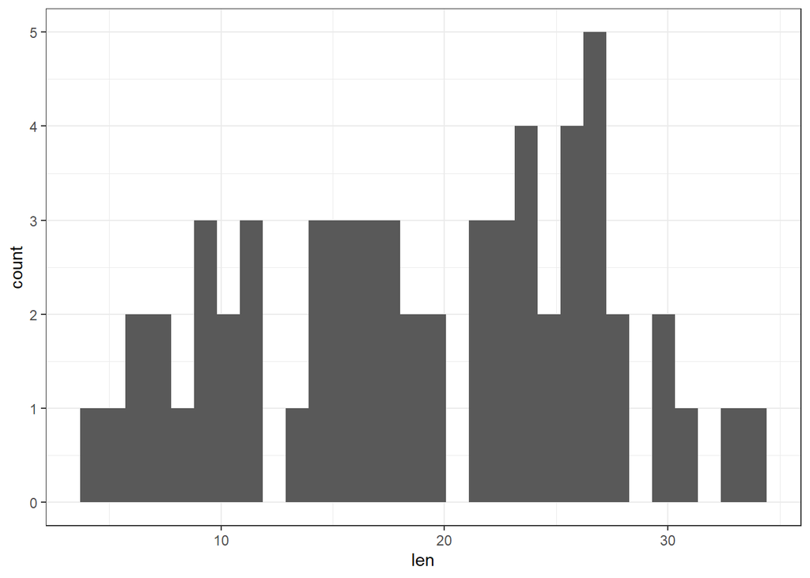

```r
ggplot(data = TG_new, aes(x = len)) +
  geom_histogram()
```

## 2.2 Histogram, version 2

Here, we’ll adjust the width of the histogram’s bins, and we’ll also specify the color we want to use to fill the bars and the color that should separate the bars from the background.

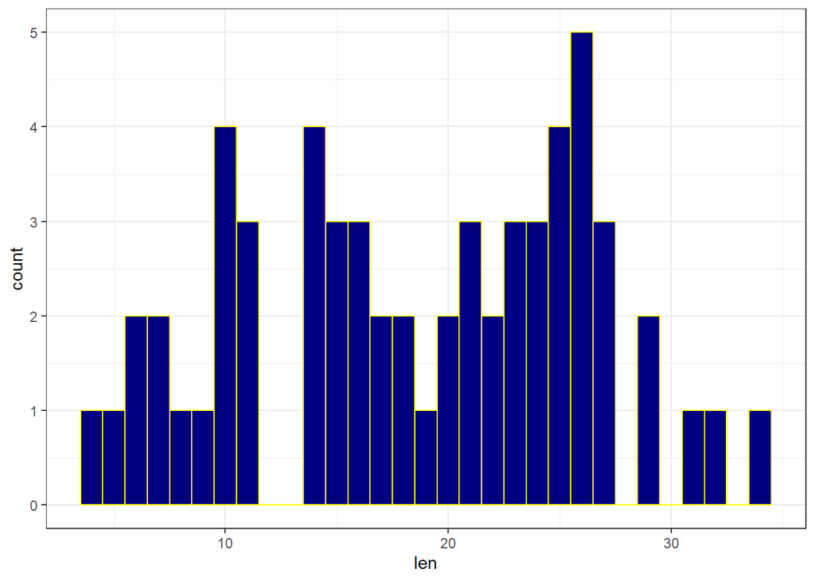

```r
ggplot(data = TG_new, aes(x = len)) +
  geom_histogram(binwidth = 1, fill = "navy", col = "yellow")
```

Here’s a list of the 657 named [colors in R](https://derekogle.com/NCGraphing/resources/colors).

## 2.3 Histogram, version 3

Rather than specifying a binwidth, we’ll try just setting the number of bins to 10, and see what the computer comes up with. We’ll also set up some better labels (titles for the plot itself, and for the axes.)

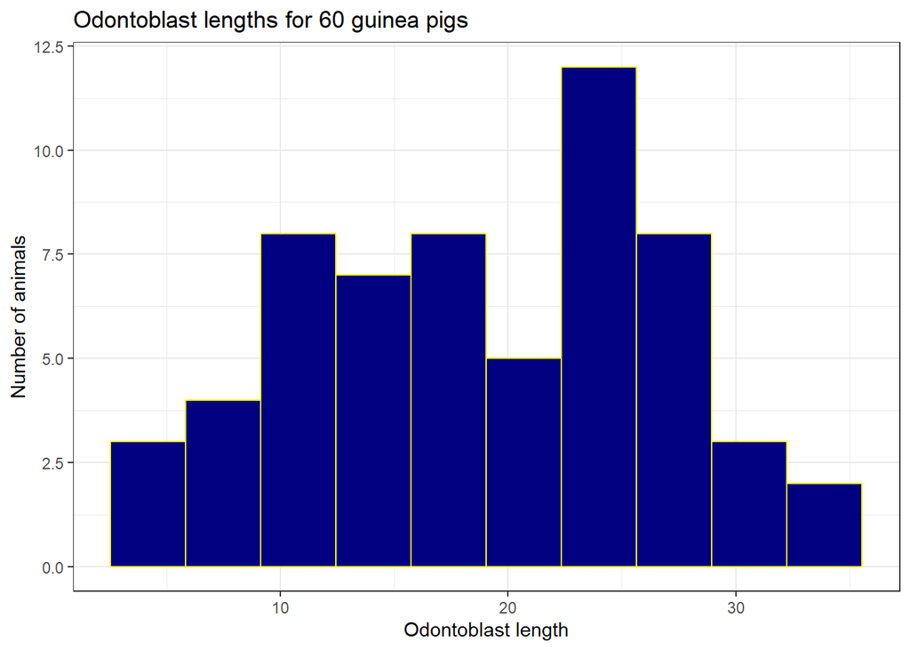

```r
ggplot(data = TG_new, aes(x = len)) +
  geom_histogram(bins = 10, fill = "navy", col = "yellow") +
  labs(title = "Odontoblast lengths for 60 guinea pigs",
       x = "Odontoblast length", y = "Number of animals")
```

# 3 Estimating the mean length with a model

We’ll fit a linear regression model using ordinary least squares (OLS) to build one possible confidence interval. What we’ll use to do this is a linear model fit with `lm()`.

```r
fit1 <- lm(len ~ 1, data = TG_new)

model_parameters(fit1, ci = 0.95) |> kable()
```

| Parameter | Coefficient | SE | CI | CI_low | CI_high | t | df_error | p |
| --- | --- | --- | --- | --- | --- | --- | --- | --- |
| (Intercept) | 18.81333 | 0.9875223 | 0.95 | 16.83731 | 20.78936 | 19.05105 | 59 | 0 |

Our 95% confidence interval for the mean odontoblast length provides a point estimate (sample mean) of 18.81 (micrometers, we believe) with a 95% confidence interval ranging from 16.84 to 20.79 micrometers.

# 4 How is `dose` related to `len`gth?

## 4.1 What to do about `dose`?

The guinea pigs were randomly allocated to receive one of three doses:

- 0.5 mg/day
- 1.0 mg/day
- 2.0 mg/day

with 20 animals at each `dose`.

- How can we picture the relationship between `dose` and odontoblast length (`len`)?

## 4.2 Plotting `len` by `dose` in a scatterplot?

Let’s build the simplest possible scatterplot, by specifying what should go on the x and y axes, and using `geom_point()` to plot the data.

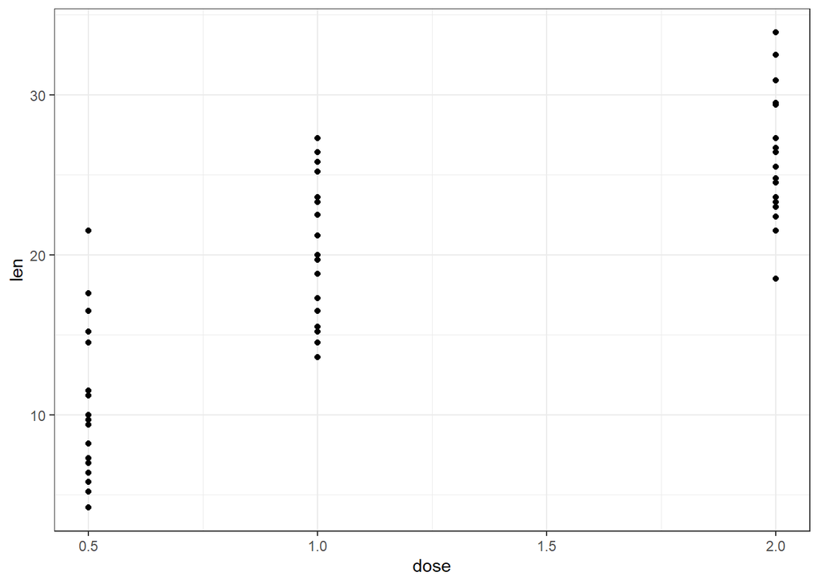

```r
ggplot(TG_new, aes(x = dose, y = len)) +
  geom_point()
```

## 4.3 Violin plot, separating the doses

There are only three doses used in this experiment. Let’s plot again, but now treating `dose` as a categorical *factor* and adding a violin to the plots.

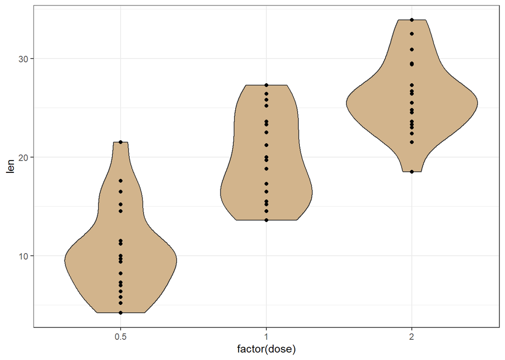

```r
ggplot(TG_new, aes(x = factor(dose), y = len)) +
  geom_violin(fill = "tan") +
  geom_point()
```

## 4.4 Numerical summary (`len` by `dose`)

```r
TG_new <- TG_new |> mutate(dose_f = as_factor(dose))

TG_new |> reframe(lovedist(len), .by = dose_f)
```

```
# A tibble: 3 × 11
  dose_f     n  miss  mean    sd   med   mad   min   q25   q75   max
  <fct>  <int> <int> <dbl> <dbl> <dbl> <dbl> <dbl> <dbl> <dbl> <dbl>
1 0.5       20     0  10.6  4.50  9.85  4.00   4.2  7.22  12.2  21.5
2 1         20     0  19.7  4.42 19.2   5.78  13.6 16.2   23.4  27.3
3 2         20     0  26.1  3.77 26.0   3.71  18.5 23.5   27.8  33.9
```

When assessing the center of these distributions by dose, does it seem to matter whether we use a mean or a median?

# 5 Ignoring dose, how does supply method relate to length?

The guinea pigs were also randomly allocated to receive either ascorbic acid (`supp` = VC) or orange juice (`supp` = OJ) so that we have 30 animals with each supply method.

## 5.1 Visual Summary

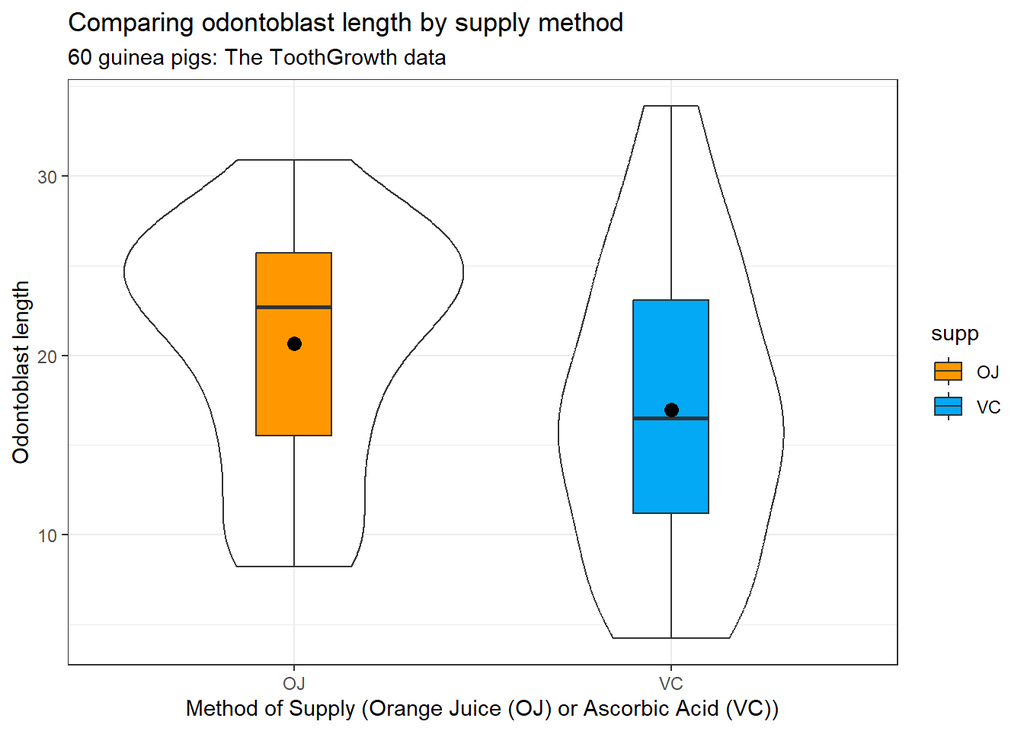

```r
ggplot(TG_new, aes(x = supp, y = len)) +
    geom_violin() +
    geom_boxplot(aes(fill = supp, width = 0.2)) +
    stat_summary(fun = mean, geom = "point", size = 3, col = "black") +
    scale_fill_metro(palette = "light", reverse = TRUE) +
    labs(title = "Comparing odontoblast length by supply method",
         subtitle = "60 guinea pigs: The ToothGrowth data",
         x = "Method of Supply (Orange Juice (OJ) or Ascorbic Acid (VC))",
         y = "Odontoblast length")
```

## 5.2 Numerical Summary

```r
TG_new |> group_by(supp) |>
    reframe(lovedist(len)) |>
    kable()
```

| supp | n | miss | mean | sd | med | mad | min | q25 | q75 | max |
| --- | --- | --- | --- | --- | --- | --- | --- | --- | --- | --- |
| OJ | 30 | 0 | 20.66333 | 6.605561 | 22.7 | 5.48562 | 8.2 | 15.525 | 25.725 | 30.9 |
| VC | 30 | 0 | 16.96333 | 8.266029 | 16.5 | 9.26625 | 4.2 | 11.200 | 23.100 | 33.9 |

## 5.3 Estimate Difference in Means with Confidence Interval?

We’ll fit a linear regression model using ordinary least squares (OLS) to build one possible confidence interval.

```r
fit2 <- lm(len ~ (supp == "OJ"), data = TG_new)

model_parameters(fit1, ci = 0.95) |> kable()
```

[output not shown]

Our 95% confidence interval for the difference in mean length suggests that the OJ animals had odontoblasts that were 3.7 μm longer, with a 95% confidence interval ranging from -0.17 to 7.57 μm.

**Note**

Notice the change when we fit the model without specifying the direction of effect that interests us.

```r
fit2_revised <- lm(len ~ supp, data = TG_new)

model_parameters(fit2_revised, ci = 0.95) |> kable()
```

| Parameter | Coefficient | SE | CI | CI_low | CI_high | t | df_error | p |
| --- | --- | --- | --- | --- | --- | --- | --- | --- |
| (Intercept) | 20.66333 | 1.366020 | 0.95 | 17.928947 | 23.3977198 | 15.126668 | 58 | 0.0000000 |
| suppVC | -3.70000 | 1.931844 | 0.95 | -7.567006 | 0.1670064 | -1.915268 | 58 | 0.0603934 |